# Assignment 5

Halka Hanna

```python
import matplotlib.pyplot as plt
import numpy as np
import pandas as pd

from sklearn.metrics import mean_squared_error, mean_absolute_error
from statsmodels.tsa.holtwinters import ExponentialSmoothing

import warnings
warnings.filterwarnings('ignore')
```

## Daily Temperature

```python
tempt = pd.read_csv('../data/daily_tempt.csv')
tempt['data_ind'] = tempt['Date']
tempt = tempt.set_index('data_ind')
tempt.index = pd.to_datetime(tempt.index)
```

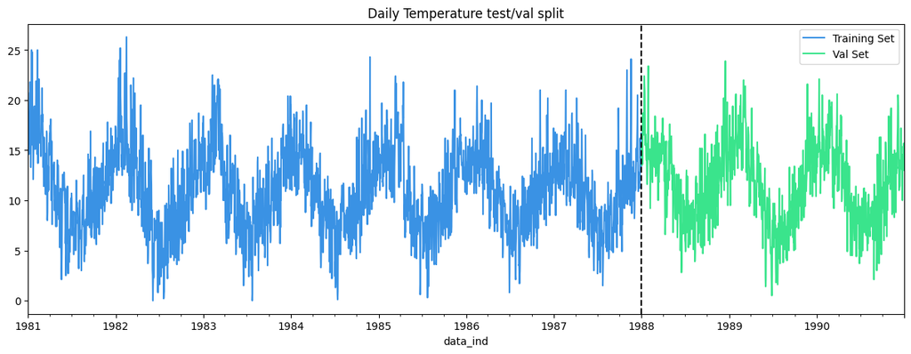

```python
train_tempt = tempt.loc[tempt.index < '1988-01-01']
val_tempt = tempt.loc[tempt.index >= '1988-01-01']

y_train = train_tempt['mean-tempt']
y_val = val_tempt['mean-tempt']

fig, ax = plt.subplots(figsize=(15, 5))
train_tempt.plot(ax=ax, label='Training Set', title='Daily Temperature test/val split', color='#3A92E4')
val_tempt.plot(ax=ax, label='Val Set', color='#3AE48C')
ax.axvline('1988-01-01', color='black', ls='--')
ax.legend(['Training Set', 'Val Set'])
plt.show()
```

My series has an additive seasonality amplitude is almost constant, and also series has not a clear trend.

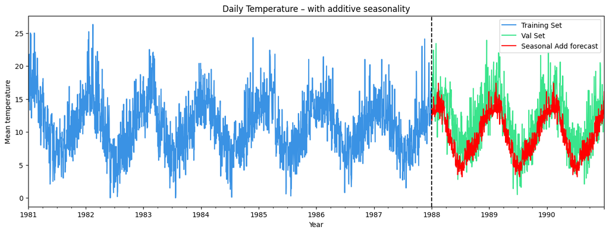

```python
seasonal_add_model = ExponentialSmoothing(
    y_train,
    trend=None,
    seasonal='add',
    seasonal_periods=365
)

seasonal_add_fit = seasonal_add_model.fit(optimized=True)
seasonal_add_forecast = seasonal_add_fit.forecast(len(y_val))

fig, ax = plt.subplots(figsize=(15, 5))

y_train.plot(ax=ax, label='Training Set', color='#3A92E4')
y_val.plot(ax=ax, label='Val Set', color='#3AE48C')
seasonal_add_forecast.plot(ax=ax, label='Seasonal Add forecast', color='red')

ax.axvline('1988-01-01', color='black', ls='--')
ax.set_ylabel("Mean temperature")
ax.set_xlabel("Year")
ax.set_title('Daily Temperature – with additive seasonality')
ax.legend()

plt.show()
```

```python
rmse = np.sqrt(mean_squared_error(y_val, seasonal_add_forecast))
mae = mean_absolute_error(y_val, seasonal_add_forecast)
mape = np.mean(np.abs((y_val - seasonal_add_forecast) / y_val)) * 100

print(f" MAE  = {mae:.3f}; \n RMSE = {rmse:.3f}; \n MAPE = {mape:.3f}")
```

```
 MAE  = 2.821;
 RMSE = 3.492;
 MAPE = 26.786
```

There is only one model for tempt dataset, so there is nothing to compare it to.

```python
print("Additive seasonality params:\n",
      seasonal_add_fit.params)
```

[output not shown]

[output cut: 19 more lines]

[output not shown]

## Weekly CO2

```python
co2 = pd.read_csv('../data/weekly_co2.csv')
co2 = co2[['Date', 'average']]
co2['data_ind'] = co2['Date']
co2 = co2.set_index('data_ind')
co2.index = pd.to_datetime(co2.index)
```

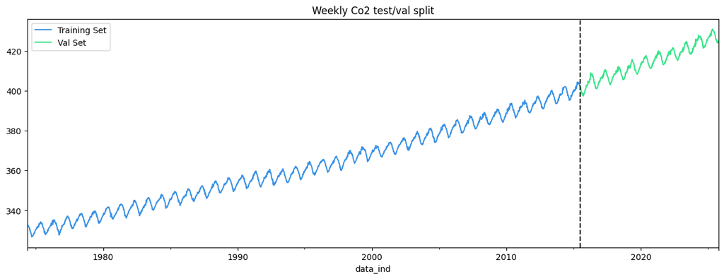

```python
train_co2 = co2.loc[co2.index < '2015-07-05']
val_co2 = co2.loc[co2.index >= '2015-07-05']

y_train = train_co2['average']
y_val = val_co2['average']

fig, ax = plt.subplots(figsize=(15, 5))
train_co2.plot(ax=ax, label='Training Set', title='Weekly Co2 test/val split', color='#3A92E4')
val_co2.plot(ax=ax, label='Val Set', color='#3AE48C')
ax.axvline('2015-07-05', color='black', ls='--')
ax.legend(['Training Set', 'Val Set'])
plt.show()
```

My series has a clear trend, and a multiplicative seasonality we will compare `seasonal_periods=52` and `seasonal_periods=104` and also we will do the same for additive seasonality.

if `damped_trend=True`:

[figure not shown]

The damped trend clearly shows itself worse than the one without damping.

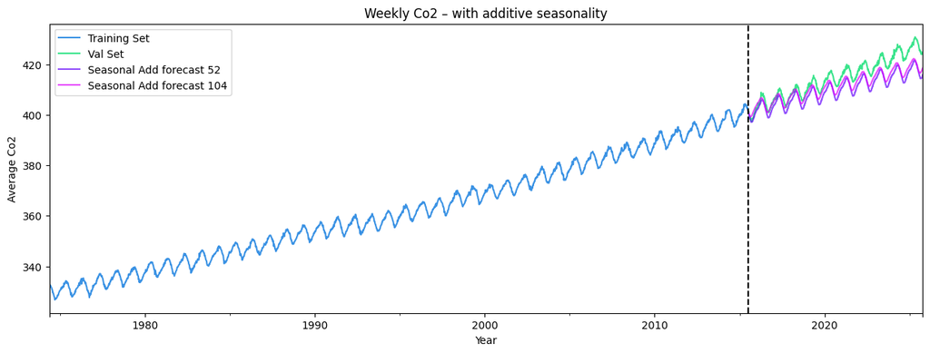

```python
# Additive seasonality 52
seasonal_add_model = ExponentialSmoothing(
    y_train,
    trend='add',
    # damped_trend=True,
    seasonal='add',
    seasonal_periods=52
)

seasonal_add_fit = seasonal_add_model.fit(optimized=True)
seasonal_add_forecast_52 = seasonal_add_fit.forecast(len(y_val))

# Additive seasonality 104
seasonal_add_model = ExponentialSmoothing(
    y_train,
    trend='add',
    # damped_trend=True,
    seasonal='add',
    seasonal_periods=104
)

seasonal_add_fit = seasonal_add_model.fit(optimized=True)
seasonal_add_forecast_104 = seasonal_add_fit.forecast(len(y_val))

fig, ax = plt.subplots(figsize=(15, 5))

y_train.plot(ax=ax, label='Training Set', color='#3A92E4')
y_val.plot(ax=ax, label='Val Set', color='#3AE48C')
seasonal_add_forecast_52.plot(ax=ax, label='Seasonal Add forecast 52', color='#6203FC', alpha=0.7)
seasonal_add_forecast_104.plot(ax=ax, label='Seasonal Add forecast 104', color='#DD03FC', alpha=0.7)

ax.axvline('2015-07-05', color='black', ls='--')
ax.set_ylabel("Average Co2")
ax.set_xlabel("Year")
ax.set_title('Weekly Co2 – with additive seasonality')
ax.legend()

plt.show()
```

We see that `seasonal_periods=104` shows itself better.

```python
# Additive seasonality 52
add_mae_52 = mean_absolute_error(y_val, seasonal_add_forecast_52)
add_rmse_52 = np.sqrt(mean_squared_error(y_val, seasonal_add_forecast_52))
add_mape_52 = np.mean(np.abs((y_val - seasonal_add_forecast_52) / y_val)) * 100
# Additive seasonality 104
add_mae_104 = mean_absolute_error(y_val, seasonal_add_forecast_104)
add_rmse_104 = np.sqrt(mean_squared_error(y_val, seasonal_add_forecast_104))
add_mape_104 = np.mean(np.abs((y_val - seasonal_add_forecast_104) / y_val)) * 100

print(f" Additive seasonality 52:   Additive seasonality 104:"
      f"\n MAE  = {add_mae_52:.3f};              MAE  = {add_mae_104:.3f};"
      f"\n RMSE = {add_rmse_52:.3f};              RMSE = {add_rmse_104:.3f};"
      f"\n MAPE = {add_mape_52:.3f};              MAPE = {add_mape_104:.3f}.")
```

```
 Additive seasonality 52:   Additive seasonality 104:
 MAE  = 4.762;              MAE  = 3.428;
 RMSE = 5.390;              RMSE = 4.240;
 MAPE = 1.139;              MAPE = 0.818.
```

```python
print("Additive seasonality 52 params:\n",
      seasonal_add_fit.params)
print()
print("Additive seasonality 104 params:\n",
      seasonal_add_fit.params)
```

[output not shown]

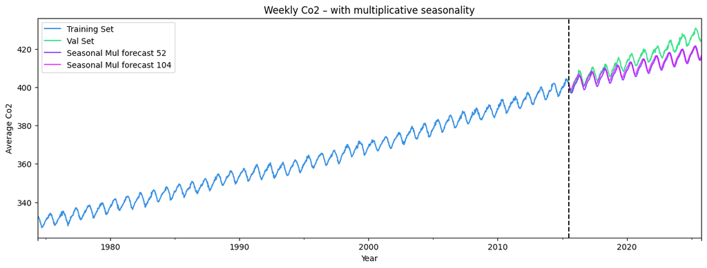

```python
# Multiplicative seasonality 52
seasonal_mul_model = ExponentialSmoothing(
    y_train,
    trend='add',
    seasonal='mul',
    seasonal_periods=52
)

seasonal_mul_fit = seasonal_mul_model.fit(optimized=True)
seasonal_mul_forecast_52 = seasonal_mul_fit.forecast(len(y_val))

# Multiplicative seasonality 104
seasonal_mul_model = ExponentialSmoothing(
    y_train,
    trend='add',
    seasonal='mul',
    seasonal_periods=104
)

seasonal_mul_fit = seasonal_mul_model.fit(optimized=True)
seasonal_mul_forecast_104 = seasonal_mul_fit.forecast(len(y_val))

fig, ax = plt.subplots(figsize=(15, 5))

y_train.plot(ax=ax, label='Training Set', color='#3A92E4')
y_val.plot(ax=ax, label='Val Set', color='#3AE48C')
seasonal_mul_forecast_52.plot(ax=ax, label='Seasonal Mul forecast 52', color='#6203FC', alpha=0.7)
seasonal_mul_forecast_104.plot(ax=ax, label='Seasonal Mul forecast 104', color='#DD03FC', alpha=0.7)

ax.axvline('2015-07-05', color='black', ls='--')
ax.set_ylabel("Average Co2")
ax.set_xlabel("Year")
ax.set_title('Weekly Co2 – with multiplicative seasonality')
ax.legend()

plt.show()
```

And again we see that `seasonal_periods=104` shows itself better. Also, we see that additive model shows itself better than multiplicative model.

```python
# Multiplicative seasonality 52
mul_mae_52 = mean_absolute_error(y_val, seasonal_mul_forecast_52)
mul_rmse_52 = np.sqrt(mean_squared_error(y_val, seasonal_mul_forecast_52))
mul_mape_52 = np.mean(np.abs((y_val - seasonal_mul_forecast_52) / y_val)) * 100
# Multiplicative seasonality 104
mul_mae_104 = mean_absolute_error(y_val, seasonal_mul_forecast_104)
mul_rmse_104 = np.sqrt(mean_squared_error(y_val, seasonal_mul_forecast_104))
mul_mape_104 = np.mean(np.abs((y_val - seasonal_mul_forecast_104) / y_val)) * 100

print(f" Multiplicative seasonality 52:   Multiplicative seasonality 104:"
      f"\n MAE  = {mul_mae_52:.3f};                    MAE  = {mul_mae_104:.3f};"
      f"\n RMSE = {mul_rmse_52:.3f};                    RMSE = {mul_rmse_104:.3f};"
      f"\n MAPE = {mul_mape_52:.3f};                    MAPE = {mul_mape_104:.3f}.")
```

```
 Multiplicative seasonality 52:   Multiplicative seasonality 104:
 MAE  = 4.909;                    MAE  = 4.225;
 RMSE = 5.529;                    RMSE = 5.158;
 MAPE = 1.175;                    MAPE = 1.008.
```

```python
print("Multiplicative seasonality 52 params:\n",
      seasonal_mul_fit.params)
print()
print("Multiplicative seasonality 104 params:\n",
      seasonal_mul_fit.params)
```

[output not shown]

## Hourly AEP

```python
aep = pd.read_csv('../data/hourly_aep.csv')
aep['data_ind'] = aep['Date']
aep = aep.set_index('data_ind')
aep.index = pd.to_datetime(aep.index)
```

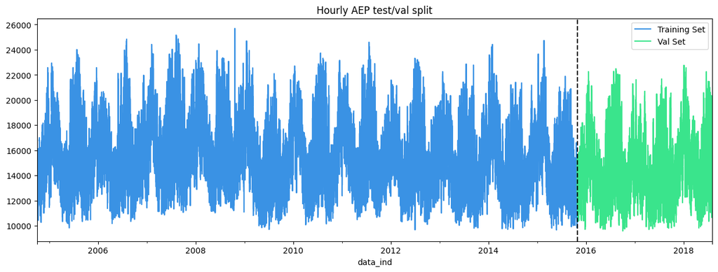

```python
train_aep = aep.loc[aep.index < '2015-10-27 06:00:00']
val_aep = aep.loc[aep.index >= '2015-10-27 06:00:00']

y_train = train_aep['AEP_MW']
y_val = val_aep['AEP_MW']

fig, ax = plt.subplots(figsize=(15, 5))
train_aep.plot(ax=ax, label='Training Set', title='Hourly AEP test/val split', color='#3A92E4')
val_aep.plot(ax=ax, label='Val Set', color='#3AE48C')
ax.axvline('2015-10-27 06:00:00', color='black', ls='--')
ax.legend(['Training Set', 'Val Set'])
plt.show()
```

My series has an additive seasonality but multiplicative seasonality we will also try, and series has not a clear trend.

[figure not shown]

```python
seasonal_add_model = ExponentialSmoothing(
    y_train,
    trend=None,
    seasonal='add',
    seasonal_periods=4464
)

seasonal_add_fit = seasonal_add_model.fit(optimized=True)
seasonal_add_forecast = seasonal_add_fit.forecast(len(y_val))

seasonal_mul_model = ExponentialSmoothing(
    y_train,
    trend=None,
    seasonal='mul',
    seasonal_periods=4464
)

seasonal_mul_fit = seasonal_mul_model.fit(optimized=True)
seasonal_mul_forecast = seasonal_mul_fit.forecast(len(y_val))

fig, ax = plt.subplots(figsize=(15, 5))

y_train.plot(ax=ax, label='Training Set', color='#3A92E4')
y_val.plot(ax=ax, label='Val Set', color='#3AE48C')
seasonal_add_forecast.plot(ax=ax, label='Seasonal Add forecast', color='#6203FC', alpha=0.7)
seasonal_mul_forecast.plot(ax=ax, label='Seasonal Mul forecast',color='#DD03FC', alpha=0.7)

ax.axvline('2015-10-27 06:00:00', color='black', ls='--')
ax.set_ylabel("Mean temperature")
ax.set_xlabel("Year")
ax.set_title('Daily Temperature – with additive seasonality')
ax.legend()

plt.show()
```

Our seasonal period is 4464, hear we're comparing additive and multiplicative seasonality.

And we see that multiplicative has better result.

```python
# Additive seasonality
add_mae = mean_absolute_error(y_val, seasonal_add_forecast)
add_rmse = np.sqrt(mean_squared_error(y_val, seasonal_add_forecast))
add_mape = np.mean(np.abs((y_val - seasonal_add_forecast) / y_val)) * 100
# Multiplicative seasonality
mul_mae = mean_absolute_error(y_val, seasonal_mul_forecast)
mul_rmse = np.sqrt(mean_squared_error(y_val, seasonal_mul_forecast))
mul_mape = np.mean(np.abs((y_val - seasonal_mul_forecast) / y_val)) * 100

print(f" Additive seasonality:  Multiplicative seasonality:"
      f"\n MAE  = {add_mae:.3f};       MAE  = {mul_mae:.3f};"
      f"\n RMSE = {add_rmse:.3f};       RMSE = {mul_rmse:.3f};"
      f"\n MAPE = {add_mape:.3f};         MAPE = {mul_mape:.3f}.")
```

```
 Additive seasonality:  Multiplicative seasonality:
 MAE  = 2487.105;       MAE  = 2414.155;
 RMSE = 3147.158;       RMSE = 3104.978;
 MAPE = 16.070;         MAPE = 15.392.
```

```python
print("Additive seasonality params:\n",
      seasonal_add_fit.params)
print()
print("Multiplicative seasonality params:\n",
      seasonal_mul_fit.params)
```

```
Additive seasonality params:
 {'smoothing_level': np.float64(0.9950191124098628), 'smoothing_trend': np.float64(nan), 'smoothing_seasonal': np.float64(0.004980887590137151), 'damping_trend': nan, 'initial_level': np.float64(15801.3643618948), 'initial_trend': np.float64(nan), 'initial_seasons': array([-3063.31714251, -3506.1538…
        -560.92774349, -1304.00288494, -2275.85274543], shape=(4464,)), 'use_boxcox': False, 'lamda': None, 'remove_bias': False}

Multiplicative seasonality params:
 {'smoothing_level': np.float64(0.9999999850988388), 'smoothing_trend': np.float64(nan), 'smoothing_seasonal': np.float64(1.4901161193847656e-08), 'damping_trend': nan, 'initial_level': np.float64(15804.280458423218), 'initial_trend': np.float64(nan), 'initial_seasons': array([0.80907054, 0.78055291…
       0.85620718], shape=(4464,)), 'use_boxcox': False, 'lamda': None, 'remove_bias': False}
```